# Graph Analysis Project

NASR Rodrigue

NENOVSKY Nikola

2024-03-28

## Research question: Study of a network formation mechanism

*In this project, you will investigate a dyadic mechanism driving the formation of a real network. This mechanism can be related to assortativity or dissortativity on a node attribute (similar or dissimilar individuals tend to be connected), to the sociability or popularity of a node attribute (some individuals connect to more people or receive more connections), or to another network variable (individuals connected through another network tend to be connected). Please leave the instructions in italic. Attach your code as a RmD file.*

## Data preparation

```r
library(tidyverse)
```

```r
library(igraph)
library(igraphdata)
library(RColorBrewer)
library(dplyr)
library(ggplot2)
```

```r
#Importing the Data
setwd("C:/Users/Rodrigue/Desktop/X/rodrigue/Master/Master 2/S2/Graph analysis/Project")
currencies_data <- read.delim("flandreau_jobst_internationalcurrencies_data.txt", skip = 9)
```

First, we retrieve the countries information.

```r
#Countries Informations
countries_infos <- currencies_data[,c("country_A","gold","debtburden","rlong","rshort1900","rshort1890","rgdp","rgdpcap","poldemo","coverage")]
countries_infos <- unique(countries_infos)
```

Let’s identify if the country is a colonizer or not

```r
#Finding if a country is a colonizer of other countries
graph_data <- currencies_data[currencies_data$bitrade != 0 ,c("country_A","country_B","bitrade","colony")]
colonizer <- graph_data[,c("country_B","colony")]
grouped_colonizer <- colonizer %>%
  group_by(country_B) %>%
  summarize(Sum_colony = sum(colony))
grouped_colonizer$is_colonizer <- ifelse(grouped_colonizer$Sum_colony != 0 ,1 ,0)
# Add the variable is_colonizer to countries_info
countries_infos <- countries_infos %>%
  left_join(grouped_colonizer[,c("country_B","is_colonizer")], by = c("country_A" = "country_B"))
```

Then, we will create a directed graph with our dataframe.

We will also divide weights based on the trade amount, which will be used for our first plot.

```r
quantile(graph_data$bitrade)
```

```
##          0%         25%         50%         75%        100%
##      19.440    2032.068   11967.975   51156.360 3545484.000
```

Based on the quantiles, we divide into 3 categories:

1. Below 12000 USD
2. Between 12000 USD and 51000 USD
3. Greater than 51000 USD

```r
breakpoints <- c(-Inf, 12000, 51000, Inf)
graph_data$category <- cut(graph_data$bitrade, breaks = breakpoints, labels = c("green", "blue", "red"))

graph <- graph_from_data_frame(graph_data,directed = TRUE, vertices=countries_infos)
E(graph)$weight <- graph_data$bitrade
E(graph)$colony <- graph_data$colony
graph$layout <- layout_nicely(graph)
```

### First plot

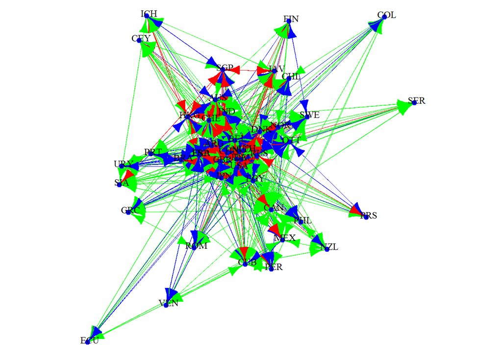

```r
par(mfrow=c(1,1), mar=rep(0,4))
plot(
  graph,
  vertex.size = 3,
  vertex.color = "blue",
  vertex.frame.color = "blue",
  vertex.label.cex = 0.8,
  vertex.label.color = "black",
  vertex.label.dist = 0.3,
  edge.width = 0.1,
  edge.cex = 1,
  edge.color = as.character(graph_data$category),
)
```

As we can see, the total trade is higher in the center of the graph (blue and red edges), which shows that there is a group of central countries which have a big number of connections with a high trade value, while being the central home of the currency implied in the trade.

## Centralities

### Pagerank centrality

We want to measure how much the importance of a node in our graph depends on the importance of its neighbors. To do so, instead of using eigenvector centrality,since our graph is directed, we will use pagerank centrality.

Let’s compute it for all nodes, then we check its correlation with the two variables rgdp (log 1900 real gdp) and gold (1 if country_A has a currency convertible in gold in 1900 and 0 otherwise.)

We expect there to be a correlation between rgdp and pagerank centrality: Indeed, economically stronger countries often have more resources to invest in infrastructure, technology and international relations, which can lead to greater connectivity and influence across the world. This may be due to their location and their influential system.

Also, we expect pagerank centrality to be linked to convertability in gold. This is because in the 1900s, particularly during the late 19th and early 20th centuries, the gold standard was indeed a prevalent monetary system in many parts of the world. So for trading purposes, talking in gold can be sometimes easier, to have a clearer vision on the value of the goods traded, and so trade negotiation could be more successful between gold convertible money countries.

```r
c_page_rank <- page_rank(graph,directed = T, weights = E(graph)$weight)$vector

df <- data.frame(rgdp = V(graph)$rgdp,
                 gold = V(graph)$gold,
                 page_rank = c_page_rank)
```

Now let us see graphically the correlation between the variables and the pagerank centrality.

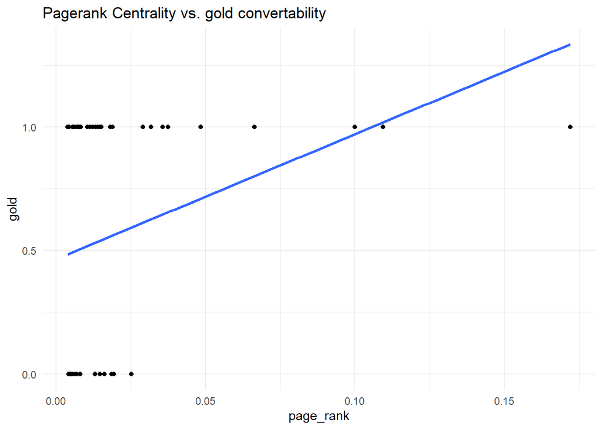

```r
ggplot(df, aes(x = page_rank, y = gold)) +
  geom_point() +
  geom_smooth(method = "lm", se = FALSE)+
  theme_minimal()+
  ggtitle("Pagerank Centrality vs. gold convertability")
```

Apparently, these two variables are positively correlated.

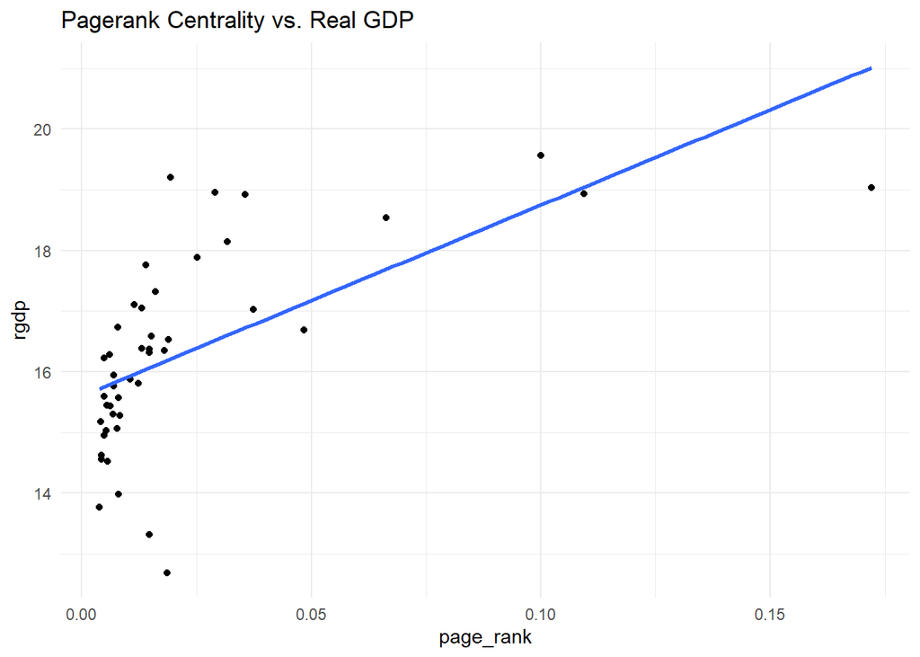

```r
ggplot(df, aes(x = page_rank, y = rgdp)) +
  geom_point() +
  geom_smooth(method = "lm", se = FALSE)+
  theme_minimal()+
  ggtitle("Pagerank Centrality vs. Real GDP")
```

Graphically, positive correlation can be seen between rgpd and pagerank value centrality.

We will confirm correlation for both variables with a correlation test.

### Correlation test

```r
cor.test(c_page_rank, V(graph)$gold)
```

```
##
##  Pearson's product-moment correlation
##
## data:  c_page_rank and V(graph)$gold
## t = 2.257, df = 43, p-value = 0.02914
## alternative hypothesis: true correlation is not equal to 0
## 95 percent confidence interval:
##  0.0352932 0.5650125
## sample estimates:
##       cor
## 0.3254555
```

We get a correlation coefficient of 0.325 with a p-value of 0.029, so we can conclude that, at a 5% level, while being a little low, we cannot deny that we have a positive correlation between having a currency convertible in gold and being influential in the network.

```r
cor.test(c_page_rank, V(graph)$rgdp)
```

```
##
##  Pearson's product-moment correlation
##
## data:  c_page_rank and V(graph)$rgdp
## t = 5.1459, df = 43, p-value = 6.269e-06
## alternative hypothesis: true correlation is not equal to 0
## 95 percent confidence interval:
##  0.3954821 0.7711424
## sample estimates:
##       cor
## 0.6173495
```

### Centrality visualization

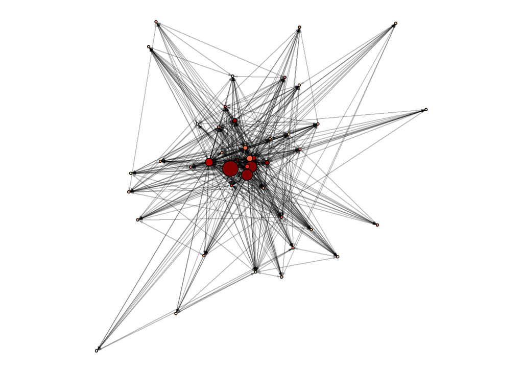

```r
par(mfrow=c(1,1), mar=rep(0,4))
colors_rgdp <- scales::dscale(V(graph)$rgdp %>% cut(9), sequential_pal)
sizes_pagerank <- (1:9)[c_page_rank %>% cut(9)] + 1
plot(graph,
     vertex.size = sizes_pagerank,
     vertex.color = colors_rgdp,
     vertex.label = NA,
     edge.color = rgb(0,0,0,.15),
     edge.arrow.size = 0.2,
     )
```

### Degree centrality and being a colonizer

Now we will see if a colonizer node will have a high degree centrality.

Degree centrality is defined by the number of neighbors of a node.

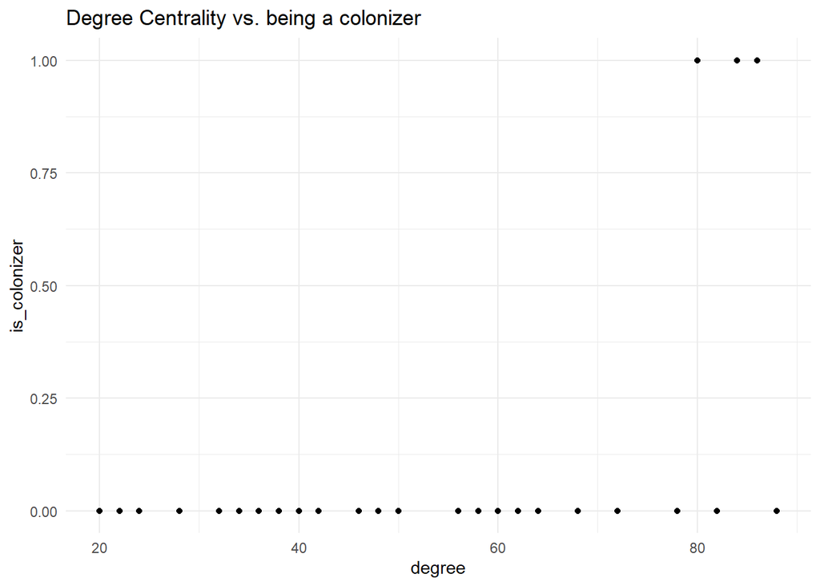

```r
c_degree <- degree(graph)

df_degree <- data.frame(is_colonizer = V(graph)$is_colonizer,
                 degree = c_degree)
ggplot(df_degree, aes(x = degree, y = is_colonizer)) +
  geom_point() +
  theme_minimal()+
  ggtitle("Degree Centrality vs. being a colonizer")
```

As we can see, colonizers have high degree centrality.

That was expected since a colonized country have many economic, financial, and political relations with the colonizer, and so they would use the colonizer’s currency for their trades, especially since colonizer usually tend to export and import a lot from and to the colony.

## Finding communities

Being in the case of a directed graph, supposing also that a country with many trade edges has thus a powerful currency, and so powerful countries should attract a lot of less powerful countries to them. We expect to find clusters of:

1. powerful currency countries
2. countries with low money power
3. and maybe a third class of in-between countries

We will use spectral clustering taking into account weights associated to each edge. Let us first calculate the Laplacian matrix Normalised and plot the eigenvalues. The Laplacian is an alternative matrix representation of the graph (vertex similarity).

$𝐿=𝐷−𝐴$

with 𝐴 the adjacency matrix, and 𝐷 a diagonal matrix storing degrees. We will here use the weighted degrees for the calculation of the Laplacian matrix.

Here we will also use the Laplacian matrix:

$𝐿_𝑁 = 𝐼 - 𝐷^{−1/2} 𝐴 𝐷^{1/2}$

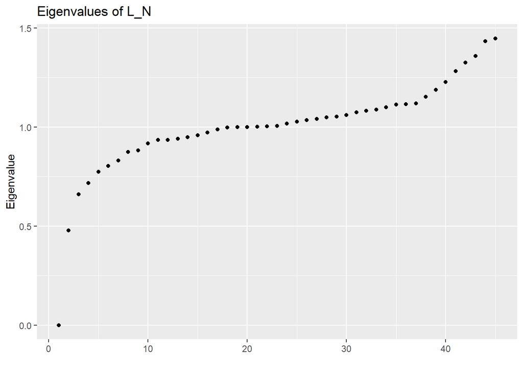

```r
graph_L <- laplacian_matrix(graph, normalized = T, sparse = F, weights = E(graph)$weight)
ggplot(as_tibble(eigen(graph_L)$values)) +
  geom_point(aes(x=1:length(value),y=sort(value))) +
  labs(x="", y="Eigenvalue", title = "Eigenvalues of L_N")
```

In our case, we select K=3, thus being in concordance with our expectations.

```r
K = 3
vect_clust <- eigen(graph_L)$vectors
vect_clust <- vect_clust[,ncol(vect_clust)-0:(K-1)]
graph_spectral <- kmeans(vect_clust, centers=K)$cluster
```

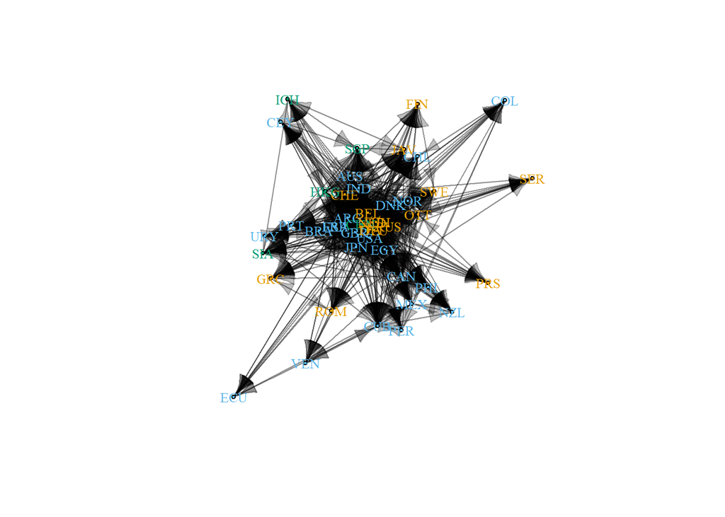

```r
plot(graph,
     vertex.size=3,
     vertex.label.cex=0.8,
     vertex.color=graph_spectral,
     vertex.label.color=graph_spectral,
     edge.color = rgb(0,0,0,.25))
```